# DRC Performance Indicators

Francisco Rios Casas

10/29/2019

## 1. Introduction

This document highlights the data completeness, data sources, and changes over time for Outcome Indicators in DRC. Data for indicators all came from the latest available Progress Update and Disbursement Request forms (PUDRs) indicated below:

| Most Recent PUDRs available |
| --- |
| Malaria_MOH_PUDR_S1 2019_LFA verified.xlsx |
| Malaria_SANRU_PUDR S1 2019_LFA verified.xlsx |
| CORDAID_PUDR_S1 2019_not verified.xlsx |
| HIV_MOH_PUDR_S1 2019_not verified.xlsx |
| Copy of LFA_COD-T-MOH_Progress Report_30Jun2019_CCF_Final_10092019.xlsx |

## 2. Data Completeness

For each Outcome Indicator, the grant Principal Recipient (PR) *usually* must establish an indicator “Baseline Value”. This value–when available–can serve as a benchmark for progress reported in subsequent time periods.

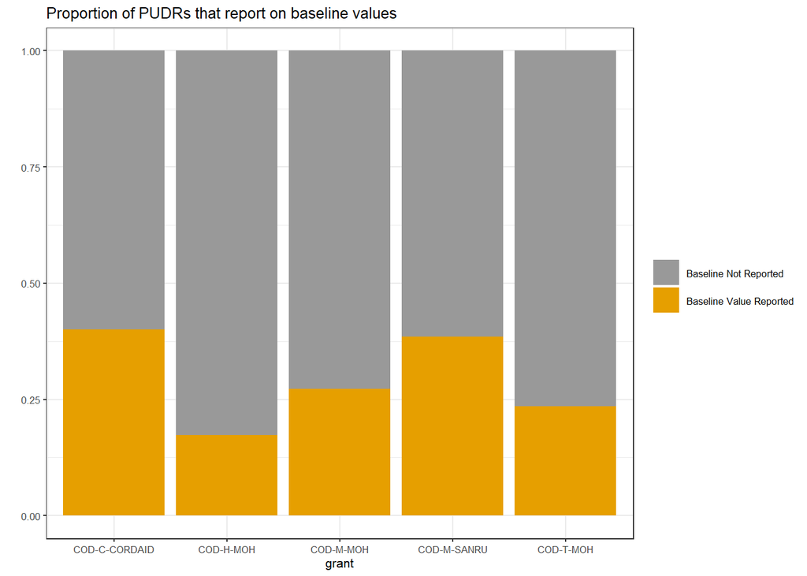

In order to calculate the achievement of an Outcome Indicator for a given grant, it is necessary to have information on (1) the target that was originally set and (2) the result.

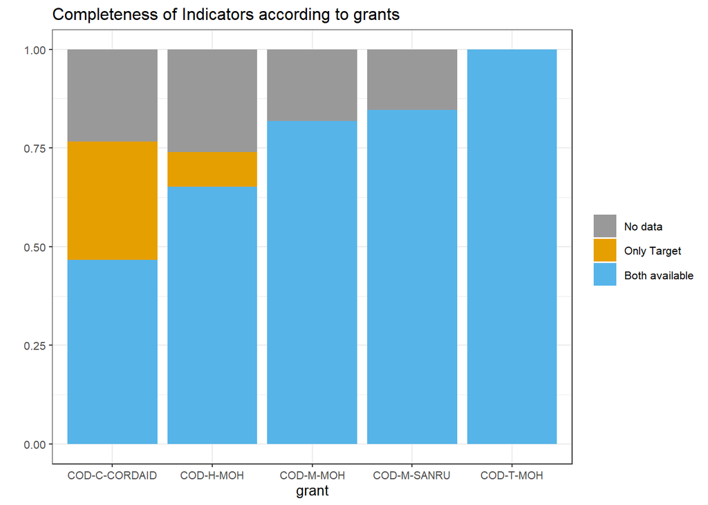

**Only the Tuberculosis grant (COD-T-MOH) provided the full data necessary to calculate progress on indicators. The two malaria grants also had a high level of data completeness (around 80%).**

## 3. Data Sources

“Data Sources” are listed in the PUDR to indicate where information reported to the global fund came from. Examples of data sources include reports from the disease-specific National Programs, surveys such as the Demographic Health Survey (DHS), and Health Management Information systems such as DHIS2.

| Grant | Indicators | Different Sources between Baseline and Result |
| --- | --- | --- |
| COD-M-MOH | 11 | 6 |
| COD-M-SANRU | 13 | 4 |
| COD-C-CORDAID | 30 | 0 |
| COD-H-MOH | 23 | 12 |
| COD-T-MOH | 17 | 13 |

**Data used to establish targets in the TB grant came from reports from the National TB Control Program, but the majority of results were obtained from the Demographic Health Survey (DHS) in the country. The majority of baseline values for the HIV grant (COD-H-MOH) indicators came from other “PUDRs”, while the results were tracked using the DHS survey as well.**

## 4. Grant Results based on most recent PUDRs

The “Achievement Ratio” is calculated in the PUDR to understand how close to the original target the Outcome Indicator result is. A value of 1.0 or greater means that the Indicators goal has been met or exceeded.

### 4.1 Malaria Grants

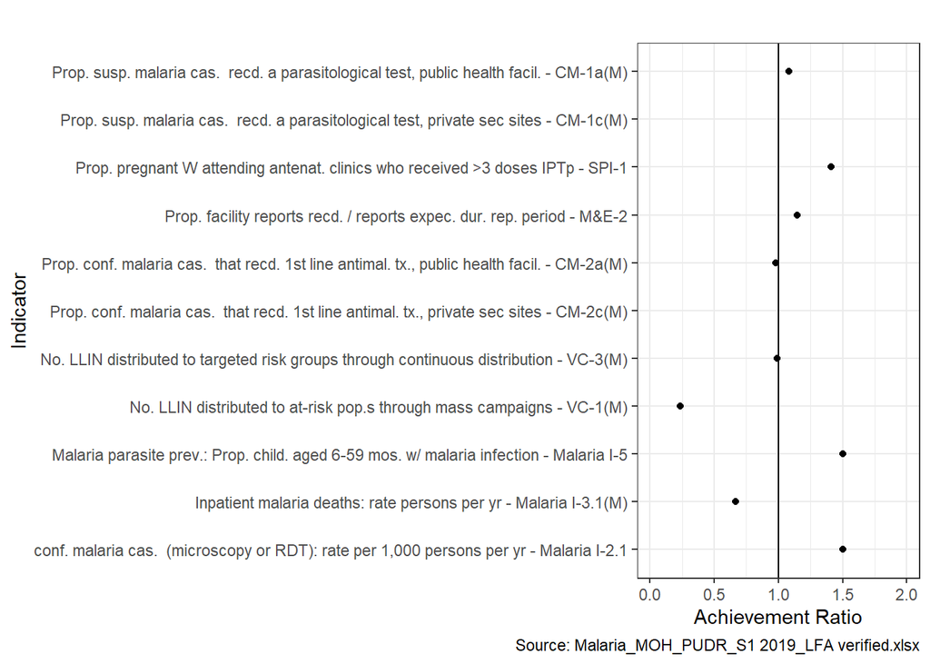

**The lowest performing indicator is the number of LLIN distributed through mass campaigns. Although Indicator I-3.1(M) is also low, in that case a lower number indicates that they are performing better than their target (less deaths related to malaria were reported than the target value.)**

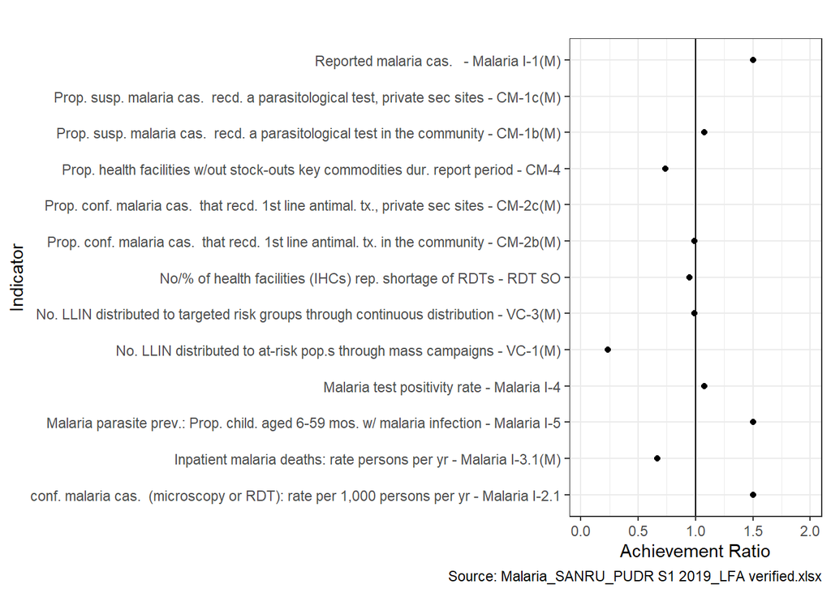

**The SANRU Malaria grant reported similar results as the MOH Malaria grant for the lowest performing indicator (Number of LLIN distributed through mass campaign). Proportion of facilities without stock outs was the other indicator showing the lowest performance. The rest of the indicators for this grant appear to be close to the planned targets.**

### 4.2 TB

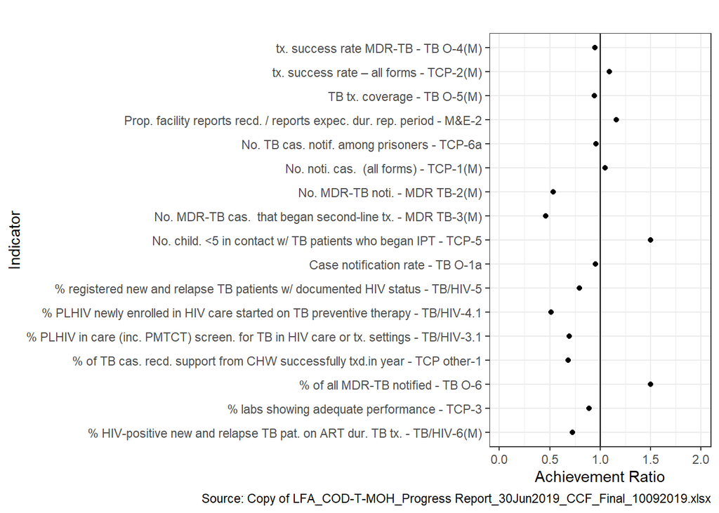

**Although several general population-wide TB targets are being met such as treatment success rate, several indicators relating to TB/HIV preventive therapy, screening, and treatment are not reaching the intended targets.**

### 4.3 HIV

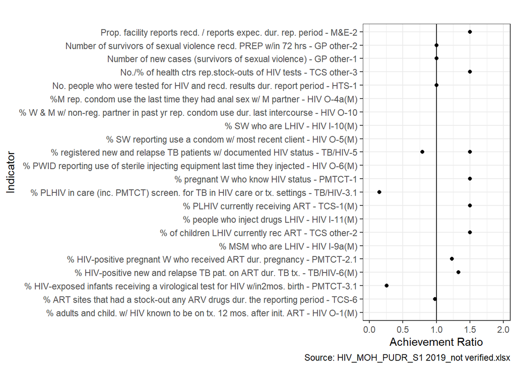

**Indicators with the lowest achievement ratios included people living with HIV who were screened for TB and HIV-exposed infants receiving a virological test for HIV shortly after birth. However, the rest of the grant’s indicators were close to target.**

### 4.4 Combined HIV/TB Grant

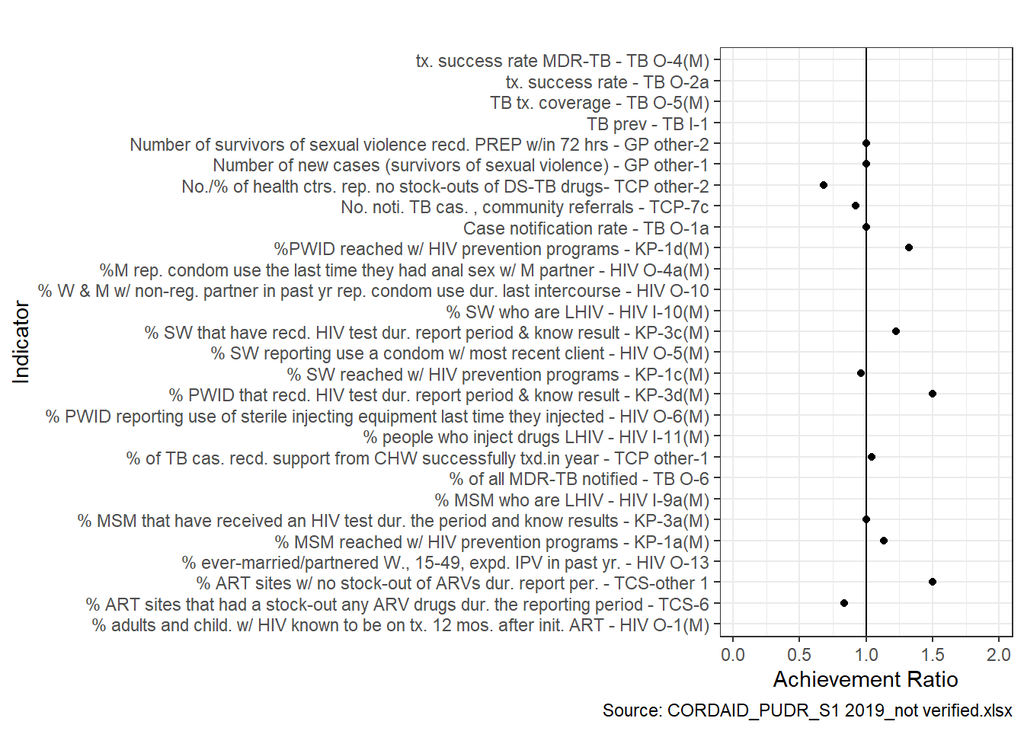

**Several indicators related to key and vulnerable populations including people who inject drugs (PWID), sex workers (SW) and men who have sex with men (MSM) were close to or exceeding their targets. However, facility-level indicators on drugs such as stock-outs for anti-TB medications and ARV drugs were not meeting expected targets.**

## 5. Agreement between PR, LFA

After each PUDR is submitted by the PR, the LFA will verify the results reported on the Indicators. In some cases they may revise the original values provided by the PR.

The most recent LFA-verified PUDRs for this analysis include the following:

| LFA Verified PUDR Files |
| --- |
| Malaria_MOH_PUDR_S1 2019_LFA verified.xlsx |
| Malaria_SANRU_PUDR S1 2019_LFA verified.xlsx |
| LFA_Review_COD-C-CORDAID_PU 30 June 2018_Sent_27092018_OK.xlsx |
| LFA Review_COD-H-MOH_Progress Report_30Jun2018_07092018 ok_Sent 01102018.OK.xlsx |
| Copy of LFA_COD-T-MOH_Progress Report_30Jun2019_CCF_Final_10092019.xlsx |

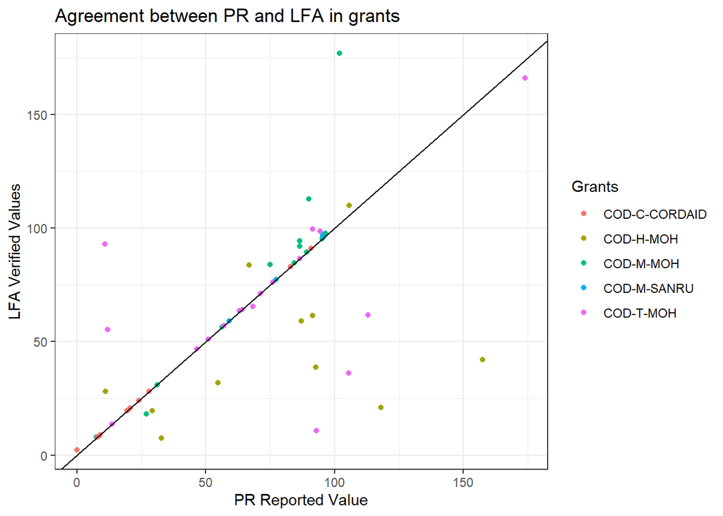

**In general, the TB grant and HIV grants to the MOH had the most revisions made by the GF LFA. In some cases the GF LFA increased the GF Reported Result Values, but when usually their edits were in order to decrease the reported values.**

## 6. Results Over Time

The tables below highlights how indicators available in the three most recent PUDRs have changed over time for each of the grants.

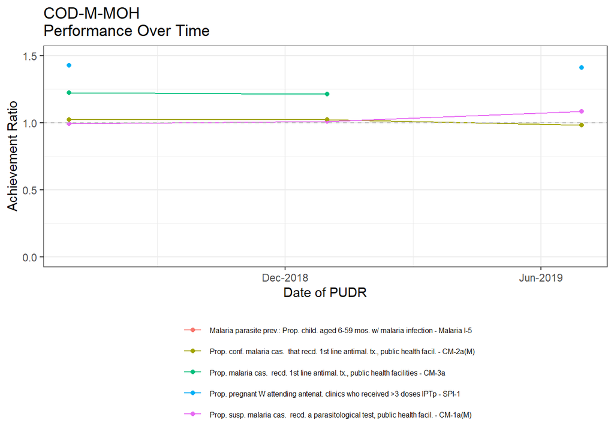

**There has been relatively little change in the Malaria grant MOH indicators (among those indicators with multiple time-points of data available).**

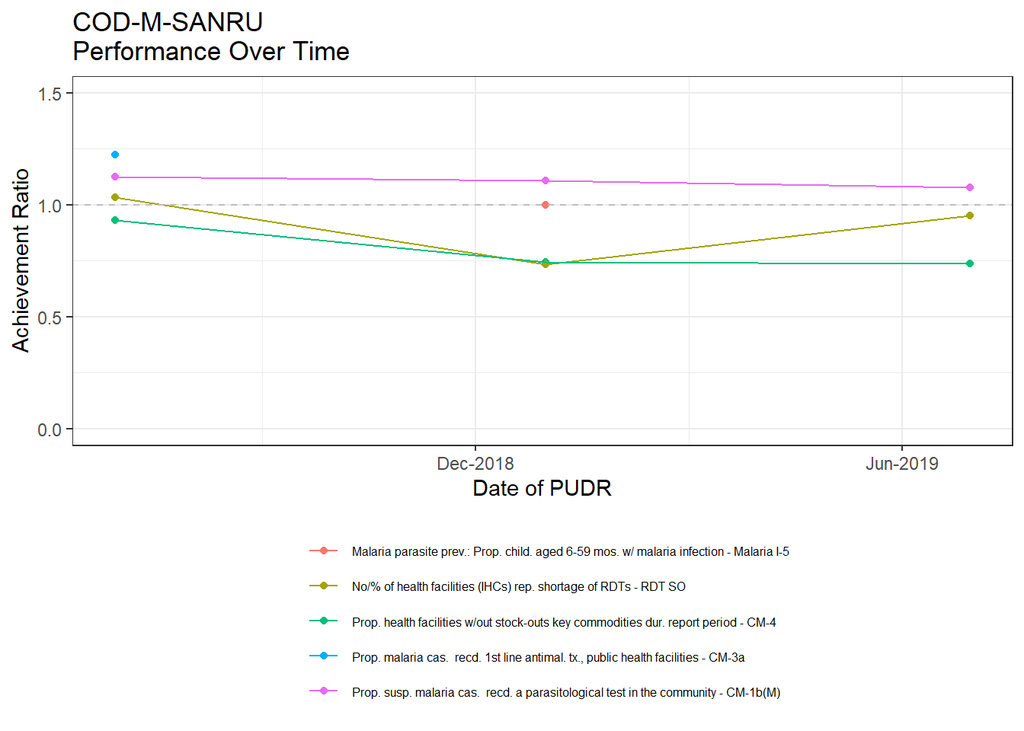

**Health facility shortages in RDTs and other “key commodities” have remained at slightly below target for the past few semesters.**

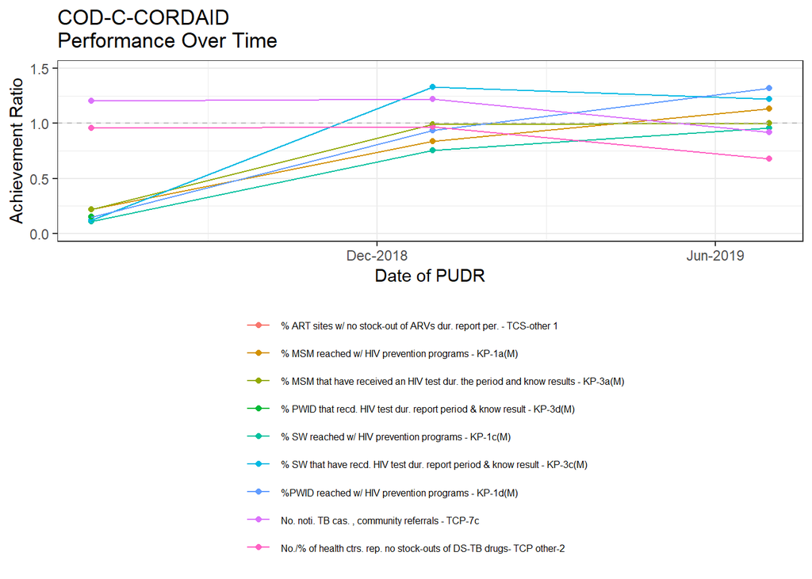

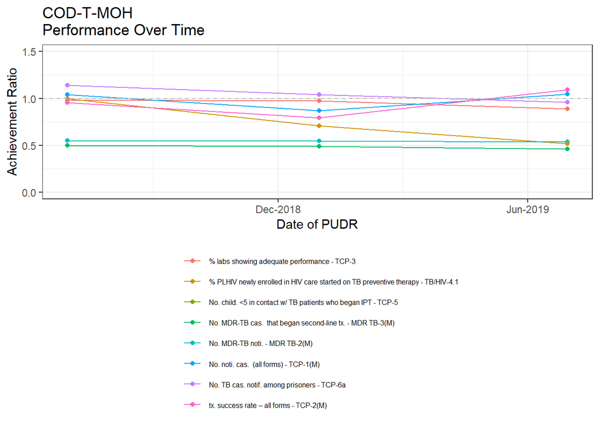